# 7. Seasonal ARIMA

# (7-2) Seasonal ARIMA

[Nao Mimoto](https://nmimoto.github.io/) - [Dept. of Statistics](http://www.uakron.edu/stat/) : [The University of Akron](http://www.uakron.edu)

[TS Class Web Page](https://nmimoto.github.io/477/) – [R resource page](https://nmimoto.github.io/R/)

# 1. SARIMA model

- Suppose there’s an annual correlation on monthly data?

  (i.e. Aug 2015 will depend on Aug 2014, Aug 2013, and so on)
- Jan 2015 will depend on Jan 2014, Jan 2013, and so on…
- That’s autocorrelation with lag 12.
- Consider MA(12) with only one coefficient, $\theta_{12} = \Theta$
  $$X_t = e_t - \Theta e_{t-12}.$$
- Calculate ACVF,
  $$\begin{align*}
  \gamma(1) \hspace{3mm} &= \hspace{3mm} \mbox{Cov}(X_{t+1}, X_t)
  \hspace{3mm} = \hspace{3mm} \mbox{Cov}\Big(e_{t+1}-\Theta e_{t-11}, \hspace{3mm} e_t-\Theta e_{t-12}\Big) = 0 \\\\
  \gamma(12) \hspace{3mm} &= \hspace{3mm} \mbox{Cov}(X_{t+12}, X_t)
  \hspace{3mm} = \hspace{3mm} \mbox{Cov}\Big(e_{t+12}-\Theta e_{t}, \hspace{3mm} e_t-\Theta e_{t-12}\Big) = - \Theta \sigma^2 .
  \end{align*}$$

There’s correlation only at lag 12.

## Seasonal MA(Q) with $s=12$

- $$\begin{align*}
  X_t \hspace{3mm} &= \hspace{3mm} e_t - \Theta_1 e_{t-12} \hspace{30mm} sMA(Q=1) \hspace{5mm} \mbox{ (s=12)} \\\\
  X_t \hspace{3mm} &= \hspace{3mm} e_t - \Theta_1 e_{t-12} - \Theta_2 e_{t-24} \hspace{15mm} sMA(Q=2) \hspace{5mm} \mbox{ (s=12)}
  \end{align*}$$
- $\gamma(h)$ will be zero except at las $s$, $2s$, $3s$, up to $Qs$.

### Representation with B

- sMA(1) s=12

  $$\begin{align*}
  X_t &= \hspace{3mm} e_t - \Theta_1 e_{t-12}\\\\
  &= \hspace{3mm} \underbrace{ (1-\Theta_1 B^{12}) }_{\mbox{seasonal char poly}} \, e_t
  \end{align*}$$
- sMA(2) s=12

  $$\begin{align*}
  X_t
  &= \hspace{3mm} e_t - \Theta_1 e_{t-12} - \Theta_2 e_{t-24} \\\\
  &= \hspace{3mm} \underbrace{ (1-\Theta_1 B^{12} - \Theta_2 B^{24}) }_{\mbox{seasonal char poly}} \, e_t
  \end{align*}$$

## Seasonal AR(P) with $s=12$

$$X_t \hspace{3mm} = \hspace{3mm} \Phi_1 X_{t-s} + e_t \hspace{30mm} \mbox{sAR(P=1)} \\\\
X_t \hspace{3mm} = \hspace{3mm} \Phi_1 X_{t-s} + \Phi_2 X_{t-2s} + e_t \hspace{15mm} \mbox{sAR(P=2)}$$

- sAR(1) period 12
  $$X_t = \Phi_1 X_{t-12} + e_t$$

  $$\begin{align*}
  \gamma(0) &= \hspace{3mm} E(X_t, X_t) \hspace{3mm} = \hspace{3mm} E[X_t \cdot (\Phi_1 X_{t-12} + e_t)] \\ \\
  &= \hspace{3mm} \Phi_1 \, \gamma(12) + E(X_t, e_t) \\ \\
  &= \hspace{3mm} \Phi_1 \, \gamma(12) + E[(\Phi_1 X_{t-12} + e_t) \cdot e_t] \\ \\
  &= \hspace{3mm} \Phi_1 \, \gamma(12) + \sigma^2
  \end{align*}$$
- For $k \geq 1$,
  $$\gamma(k)
  \hspace{3mm} = \hspace{3mm} E(X_{t-k} \, X_t)
  \hspace{3mm} = \hspace{3mm} E[ X_{t-k} \, (\Phi_1 X_{t-12} + e_t)]
  \hspace{3mm} = \hspace{3mm} \Phi_1 \gamma(k-12) + 0$$

$$\left\{
\begin{array}{ll}
\gamma(0) &= \hspace{3mm} \Phi_1 \gamma(12) + \sigma^2 \hspace{30mm} - \hspace{3mm} (2) \\
\gamma(k) &= \hspace{3mm} \Phi_1 \gamma(k-12) \,\, \mbox{ if } k \geq 1 \hspace{20mm} - \hspace{3mm} (1) \\
\end{array} \right.$$

- Take Eqn (1), $\gamma(k) = \Phi_1 \gamma(k-12)$.
  Letting $k=1$, we get
  $$\gamma(1) = \Phi_1 \gamma(-11) = \Phi_1 \gamma(11).$$
- Take (1), $k=11$
  $$\gamma(11) = \Phi_1 \gamma(-1) = \Phi_1 \gamma(1).$$
  which can only happen if
  $$\gamma(1) = 0, \mbox{ and } \gamma(11) = 0.$$
- Eqn (1) says $\gamma(k) = \Phi_1 \gamma(k-12)$. Repeating for other $k$,

  $$\begin{align*}
  \gamma(2) &= \hspace{3mm} \Phi_1 \gamma(10) = \Phi_1^2 \gamma(2) \hspace{3mm} \Rightarrow \hspace{3mm} \gamma(2) = 0, \gamma(10) = 0 \\
  \gamma(3) &= \hspace{3mm} \Phi_1 \gamma(9) = \Phi_1^2 \gamma(3) \hspace{3mm} \Rightarrow \hspace{3mm} \gamma(3) = 0, \gamma(9) = 0 \\
  &\vdots& \\
  \gamma(5) &= \hspace{3mm} \Phi_1 \gamma(7) = \Phi_1^2 \gamma(5) \hspace{3mm} \Rightarrow \hspace{3mm} \gamma(5) = 0, \gamma(7) = 0 \\
  \gamma(6) &= \hspace{3mm} \Phi_1 \gamma(6) = \Phi_1^2 \gamma(6) \hspace{3mm} \Rightarrow \hspace{3mm} \gamma(6) = 0, \gamma(6) = 0
  \end{align*}$$
- Now take Eqn (2), and Eqn (1) with $k=12$,

  $$\begin{align*}
  \gamma(0) &= \hspace{3mm} \Phi_1 \gamma(12) + \sigma^2, \\\\
  \gamma(12) &= \hspace{3mm} \Phi_1 \gamma(0)
  \end{align*}$$
- Substituting in,
  $$\gamma(0)
  \hspace{3mm} = \hspace{3mm} \Phi_1 \Big(\Phi_1 \gamma(0)\Big) + \sigma^2 \\ \\
  \hspace{3mm} = \hspace{3mm} \Phi_1^2 \gamma(0) + \sigma^2$$
- Solving, we get
  $$\gamma(0) \hspace{3mm} = \hspace{3mm} \frac{\sigma^2}{1-\Phi_1^2}, \hspace{10mm}
  \gamma(12) \hspace{3mm} = \hspace{3mm} \Phi_1 \gamma(0).$$

## ACVF for sAR(1) with s=12

For $k=1,2,3,\ldots$
$$\left\{
\begin{array}{l}
\gamma(0) = \frac{\sigma^2}{1-\Phi_1^2} \\
\gamma(k12) = \Phi_1^k \gamma(0) \\
\mbox{ otherwise } \gamma(h) = 0 \\
\end{array} \right.$$

# 2. sARIMA(p,d,q) x (P,D,Q)[s] model

- Consider sMA(1) with $s=12$ with innovation $\epsilon_t$, where $\epsilon_t \sim$ MA(1), i.e.
  $$X_t \hspace{3mm} = \hspace{3mm} \epsilon_t - \Theta_1 \epsilon_{t-12} \\
  \epsilon_t \hspace{3mm} = \hspace{3mm} e_t - \theta_1 e_{t-1}$$
- That means we have

  $$\begin{align*}
  X_t &= \hspace{3mm} (1-\Theta_1 B^{12}) \epsilon_t \\\\
  &= \hspace{3mm} (1-\Theta_1 B^{12}) (1-\theta_1 B) \, e_t
  \end{align*}$$
- This is called ARMA$(0,1) \times (0,1)_{12}$ model.

## a) Seasonal ARIMA model

- $X_t \sim \mbox{ARIMA}(p,d,q) \times (P,D,Q)_s$ means
  $$\bigtriangledown^d \bigtriangledown^D_s X_t
  \hspace{3mm} = \hspace{3mm} Y_t \sim \mbox{ARMA}(p,q) \times (P,Q)_s$$
- $Y_t \sim \mbox{ARMA}(p,q) \times (1,1)_{12}$ means
  $$\Big(1-\phi_1 B -\cdots - \phi_p B^p\Big)\Big(1-\Phi_1 B^{12}\Big) Y_t
  = \Big(1-\theta_1 B -\cdots - \theta_q B^q \Big)\Big(1-\Theta_1 B^{12}\Big) e_t$$

## b) Causality and Invertibility

Causality :
$$(1-\Phi_1 z^s) ( 1 - \phi_1 z - \cdots - \phi_p z^p) = 0$$
must have all the roots outside of the unit circle.

$$(1-\Phi_1 z^s) \hspace{3mm} = \hspace{3mm} 0 \\
( 1 - \phi_1 z - \cdots - \phi_p z^p) \hspace{3mm} = \hspace{3mm} 0$$

Similar in invertibility.

## c) Theoretical ACF

Suppose you have ARMA$(1,1) \times (0,1)_{12}$ model
$$\big(1-\phi_1 B\big) Y_t = \big(1-\theta_1 B\big)\big( 1- \Theta_1 B^{12}\big) e_t$$
Then this is same as
$$\big(1-\phi_1 B\big) Y_t = \big(1-\theta_1 B - \Theta_1 B^{12} + \theta_1 \Theta_1 B^{13} \big) e_t$$
$$\big(1- .7 B\big) Y_t = \big(1 + .7 B + .5 B^{12} + (.7)(.5) B^{13} \big) e_t$$

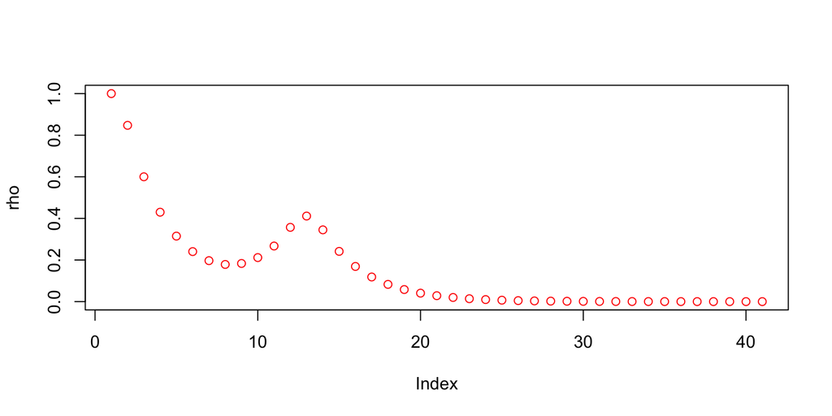

```r
    rho <- ARMAacf(ar=c(.7), ma=c( .7,0,0,0,0,0,0,0,0,0,0,.5,.35), lag.max=40)
    plot(rho, col="red")
```

# 3. CO2 data

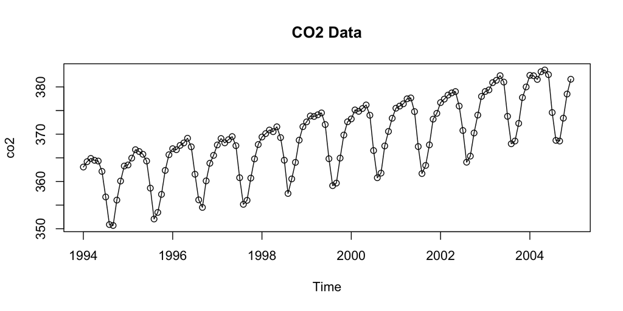

```r
  library(forecast)
  source('https://nmimoto.github.io/R/TS-00.txt')

  #- Load TSA package while protecting original acf()
  acf1 <- acf
  library(TSA)
  acf <- acf1

  data(co2)  #- we are using co2 data in TSA package (there's another one in R)

  plot(co2, type="o", main='CO2 Data')
```

```r
  frequency(co2)
```

```
## [1] 12
```

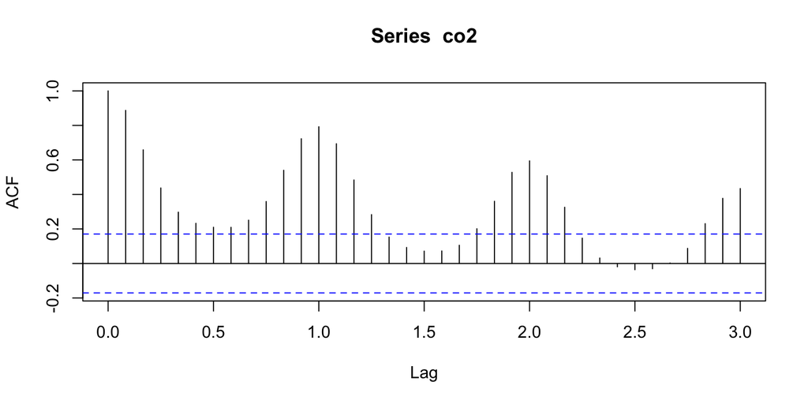

```r
  acf(co2,  lag.max=36)
```

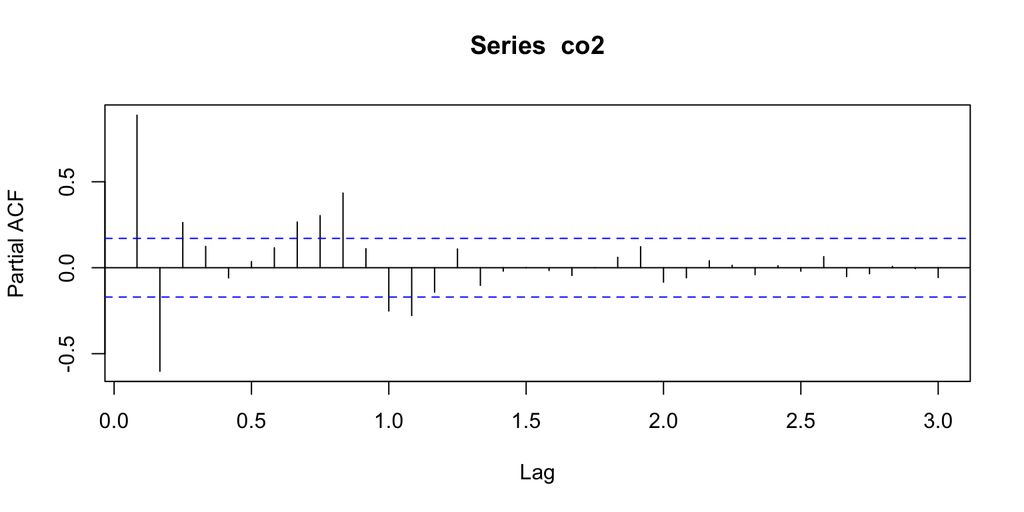

```r
  pacf(co2, lag.max=36)
```

## a) Take Del

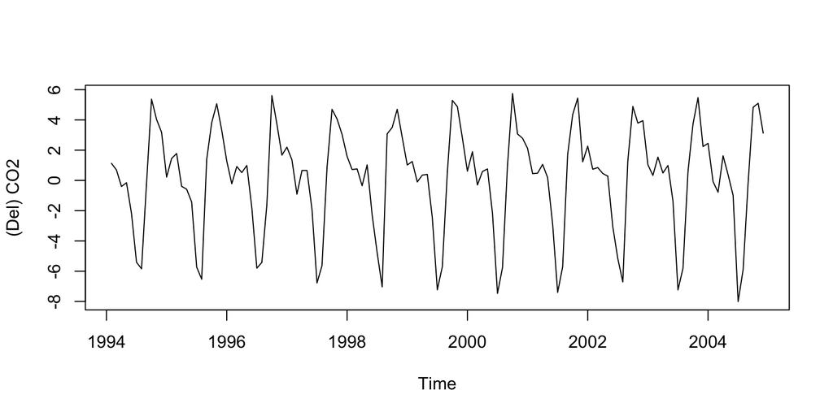

```r
  #- Take difference
  plot(diff(co2),ylab='(Del) CO2',xlab='Time')
```

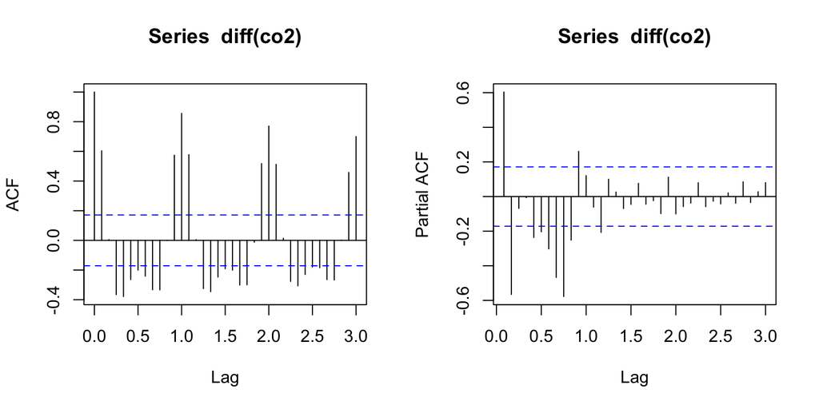

```r
  layout(matrix(1:2, 1, 2))
  acf(diff(co2)  , lag.max=36)
  pacf(diff(co2) , lag.max=36)
```

```r
  layout(1)

  Stationarity.tests( diff(co2) )
```

```
##        KPSS  ADF   PP
## p-val:  0.1 0.01 0.01
```

```r
  Fit1 = auto.arima(co2, d=1, D=0, stepwise=FALSE, approximation=FALSE)
  Fit1
```

```
## Series: co2
## ARIMA(2,1,1)(0,0,2)[12]
##
## Coefficients:
##          ar1      ar2      ma1    sma1    sma2
##       1.2124  -0.5577  -0.9166  0.6019  0.3956
## s.e.  0.0867   0.0888   0.0285  0.1063  0.0961
##
## sigma^2 estimated as 2.799:  log likelihood=-254.51
## AIC=521.01   AICc=521.69   BIC=538.26
```

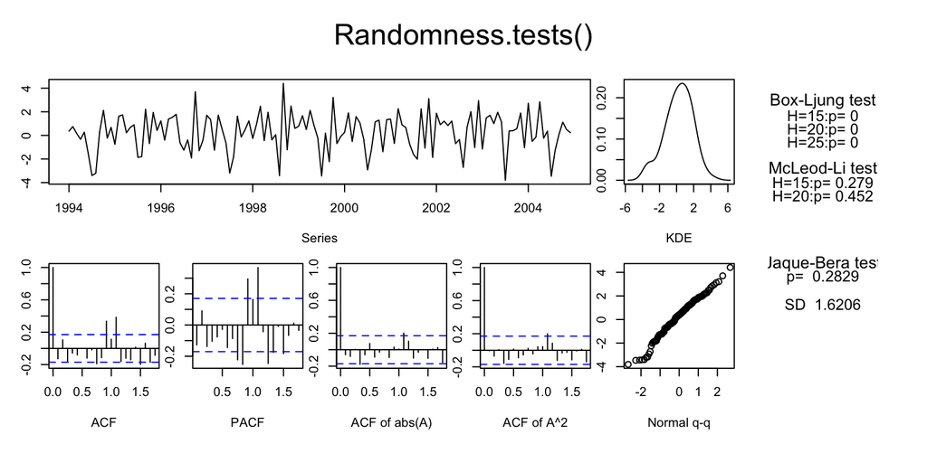

```
##   B-L test H0: the series is uncorrelated
##   M-L test H0: the square of the series is uncorrelated
##   J-B test H0: the series came from Normal distribution
##   SD         : Standard Deviation of the series
```

```
##      BL15 BL20 BL25  ML15  ML20    JB    SD
## [1,]    0    0    0 0.279 0.452 0.283 1.621
```

```r
  Randomness.tests(Fit1$residuals)
```

- just taking a difference is not enough.
- Even after fitting seasonal ARMA models, seasonal dependencies are present. Residuals are not passing the adequacy test.

## b) Take Del_12

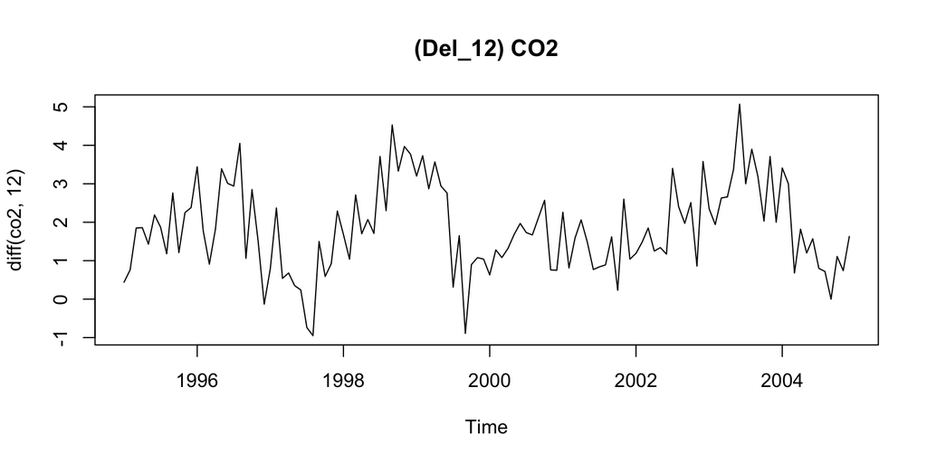

```r
  #- Take seasonal difference
  plot(diff(co2, 12), main='(Del_12) CO2', xlab='Time')
```

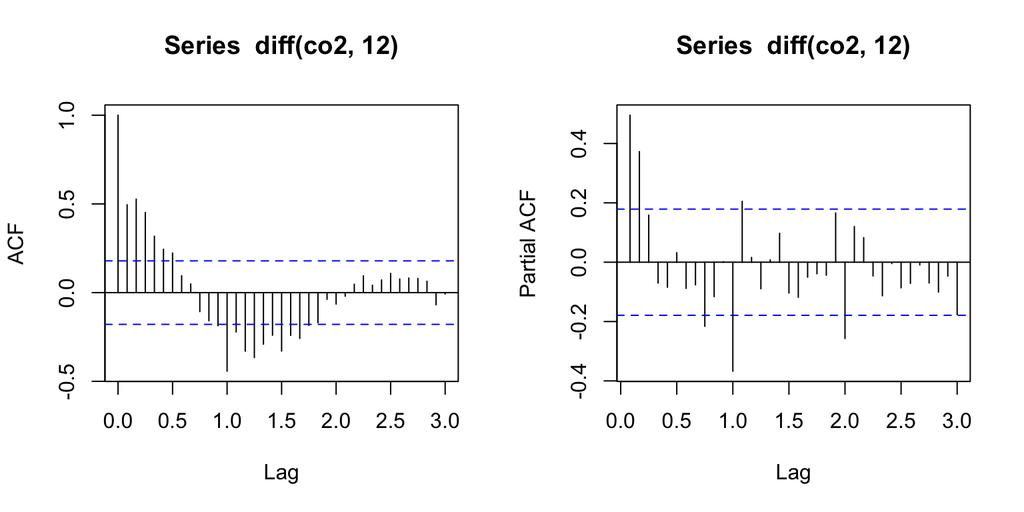

```r
  layout(matrix(1:2, 1, 2))
  acf(diff(co2, 12)  , lag.max=36)
  pacf(diff(co2, 12) , lag.max=36)
```

```r
  layout(1)

  Stationarity.tests( diff(co2, 12) )
```

```
##        KPSS   ADF   PP
## p-val:  0.1 0.157 0.01
```

```r
  Fit2 = auto.arima(co2, d=0, D=1, stepwise=FALSE, approximation=FALSE)
  Fit2
```

```
## Series: co2
## ARIMA(1,0,1)(0,1,1)[12] with drift
##
## Coefficients:
##          ar1      ma1     sma1   drift
##       0.8349  -0.4630  -0.8487  0.1520
## s.e.  0.0819   0.1246   0.1274  0.0052
##
## sigma^2 estimated as 0.5288:  log likelihood=-136.09
## AIC=282.18   AICc=282.7   BIC=296.11
```

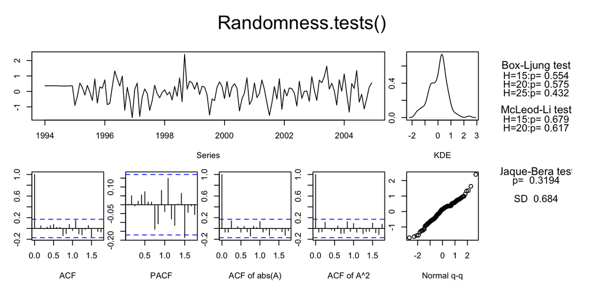

```
##   B-L test H0: the series is uncorrelated
##   M-L test H0: the square of the series is uncorrelated
##   J-B test H0: the series came from Normal distribution
##   SD         : Standard Deviation of the series
```

```
##       BL15  BL20  BL25  ML15  ML20    JB    SD
## [1,] 0.554 0.575 0.432 0.679 0.617 0.319 0.684
```

```r
  Randomness.tests(Fit2$residuals)
```

#### sARIMA(p,d,q)x(P,D,Q)[s] Model

- Stationarity is not confirmed by ADF, but KPSS says it is stationary.
- We took seasonal difference (lag 12), then fit with sARMA(1,1)x(0,1)

  $$\begin{align*}
  \bigtriangledown_{12} Y_t \hspace{3mm} &= \hspace{3mm} \delta + X_t \\ \\
  X_t \hspace{3mm} &= \mbox{ ARMA(1,1) $\times$ (0,1) } \\ \\
  (1-\phi_1 B) X_t \hspace{3mm} &= (1-\theta_1 B)(1-\Theta_1B^{12}) e_t \hspace{5mm} \mbox{ where } e_t \sim WN(0, \sigma^2)
  \end{align*}$$
  This is
  $$\mbox{ sARIMA}(p,d,q) (P,D,Q)_{12} \hspace{3mm} \\ \\
  \mbox{ sARIMA}(1,0,1) (0,1,1)_{12} \hspace{3mm} \mbox{ model }$$

```r
Fit2
```

```
## Series: co2
## ARIMA(1,0,1)(0,1,1)[12] with drift
##
## Coefficients:
##          ar1      ma1     sma1   drift
##       0.8349  -0.4630  -0.8487  0.1520
## s.e.  0.0819   0.1246   0.1274  0.0052
##
## sigma^2 estimated as 0.5288:  log likelihood=-136.09
## AIC=282.18   AICc=282.7   BIC=296.11
```

## c) Take Del and Del_12

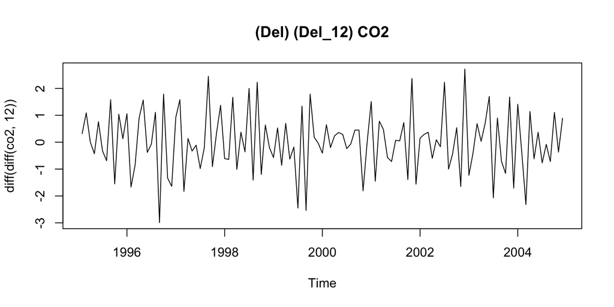

```r
  #- Take Del and Del_12 -
  plot( diff( diff(co2, 12) ), main="(Del) (Del_12) CO2" )
```

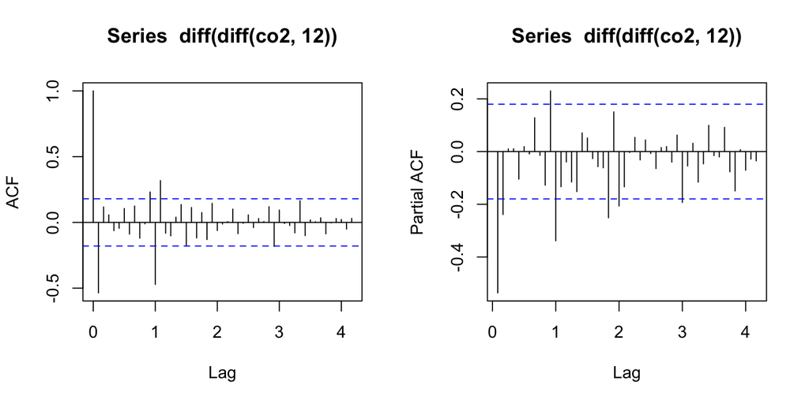

```r
  layout(matrix(1:2, 1, 2))
  acf(  diff(diff(co2, 12)), lag.max=50)
  pacf( diff(diff(co2, 12)), lag.max=50)
```

```r
  layout(1)

  Stationarity.tests( diff(diff(co2, 12)) )
```

```
##        KPSS  ADF   PP
## p-val:  0.1 0.01 0.01
```

```r
  Fit3 = auto.arima(co2, d=1, D=1, stepwise=FALSE, approximation=FALSE)
  Fit3
```

```
## Series: co2
## ARIMA(0,1,1)(0,1,1)[12]
##
## Coefficients:
##           ma1     sma1
##       -0.5792  -0.8206
## s.e.   0.0791   0.1137
##
## sigma^2 estimated as 0.5683:  log likelihood=-139.54
## AIC=285.08   AICc=285.29   BIC=293.41
```

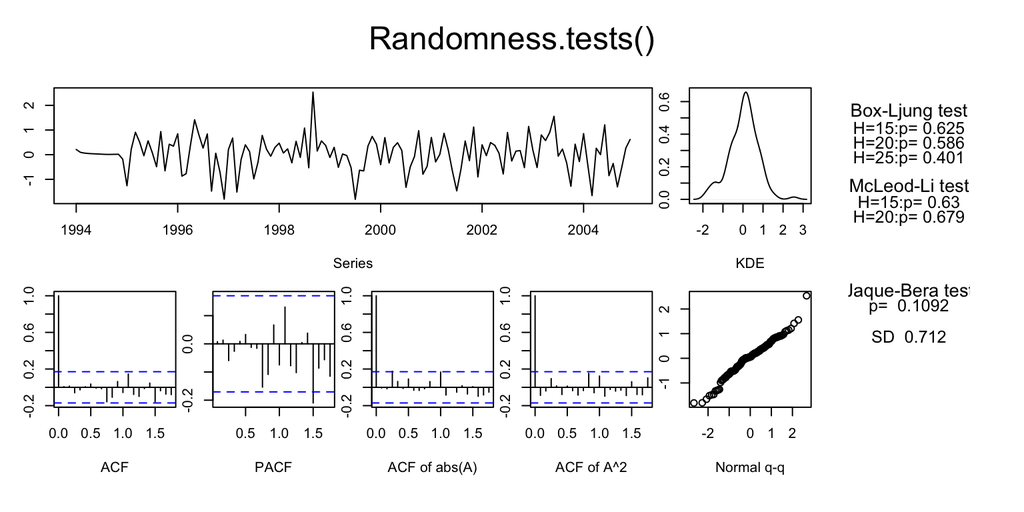

```
##   B-L test H0: the series is uncorrelated
##   M-L test H0: the square of the series is uncorrelated
##   J-B test H0: the series came from Normal distribution
##   SD         : Standard Deviation of the series
```

```
##       BL15  BL20  BL25 ML15  ML20    JB    SD
## [1,] 0.625 0.586 0.401 0.63 0.679 0.109 0.712
```

```r
  Randomness.tests(Fit3$residuals)
```

```r
  Fit4 = Arima(co2, order=c(0,1,1), seasonal=c(0,1,1) )
  Fit4
```

```
## Series: co2
## ARIMA(0,1,1)(0,1,1)[12]
##
## Coefficients:
##           ma1     sma1
##       -0.5792  -0.8206
## s.e.   0.0791   0.1137
##
## sigma^2 estimated as 0.5683:  log likelihood=-139.54
## AIC=285.08   AICc=285.29   BIC=293.41
```

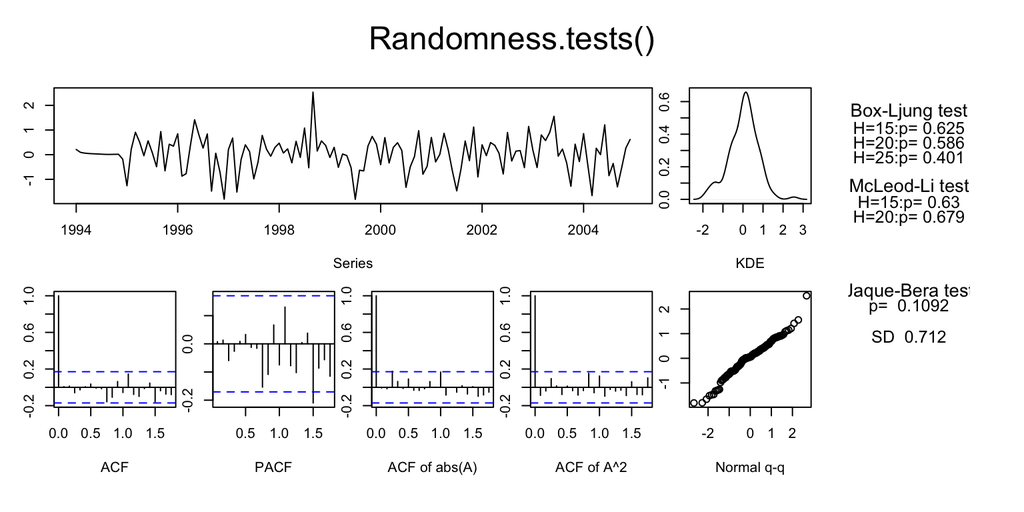

```
##   B-L test H0: the series is uncorrelated
##   M-L test H0: the square of the series is uncorrelated
##   J-B test H0: the series came from Normal distribution
##   SD         : Standard Deviation of the series
```

```
##       BL15  BL20  BL25 ML15  ML20    JB    SD
## [1,] 0.625 0.586 0.401 0.63 0.679 0.109 0.712
```

```r
  Randomness.tests(Fit4$residuals)
```

#### sARIMA(p,d,q)x(P,D,Q)[s] Model

- In part (c), We took seasonal difference (lag 12), then a difference (lag 1)

  $$\begin{align*}
  \bigtriangledown \bigtriangledown_{12} Y_t \hspace{3mm} &= \hspace{3mm} X_t \\ \\
  X_t \hspace{3mm} &= \mbox{ ARMA(0,1) $\times$ (0,1) } \\ \\
  X_t \hspace{3mm} &= (1-\theta_1 B)(1-\Theta_1B^{12}) e_t \hspace{5mm} \mbox{ where } e_t \sim WN(0, \sigma^2)
  \end{align*}$$
  This is
  $$\mbox{ sARIMA}(p,d,q) (P,D,Q)_{12} \hspace{3mm} \\ \\
  \mbox{ sARIMA}(0,1,1) (0,1,1)_{12} \hspace{3mm} \mbox{ model }$$

```r
Fit4
```

```
## Series: co2
## ARIMA(0,1,1)(0,1,1)[12]
##
## Coefficients:
##           ma1     sma1
##       -0.5792  -0.8206
## s.e.   0.0791   0.1137
##
## sigma^2 estimated as 0.5683:  log likelihood=-139.54
## AIC=285.08   AICc=285.29   BIC=293.41
```

# Summary

#### SMA(1) means that there’s MA effect from 12 month ago (when s=12).

#### ACF and PACF of SMA(1) is similar to that of MA(1), but 12 month apart.

#### SAR(1) means that there’s AR effect from 12 month ago (when s=12).

#### ACF and PACF of SAR(1) is similar to that of AR(1), but 12 month apart.

[TS Class Web Page](https://nmimoto.github.io/477/) – [R resource page](https://nmimoto.github.io/R/)